# Melbourne Housing Data EDA

Chloé Winters

2025-10-01

# 1 Introduction

This assignment will look at housing data from Melbourne Australia and start the process of regression and cross validation. Before those sections of the analysis can take place the data needs to go through exploratory data analysis and appropriate feature engineering. That is what will be covered in this first assignment.

# 2 Materials

## 2.1 Data Set

```r
url ="https://chloewinters79.github.io/STA551/Data/MelbourneHousing.csv"
house = read.csv(url, header = TRUE)
```

The data set being used in this analysis consits of 34,857 observations and 21 variables which are described below. This data set was created from publicly available results posted every week from Domain.com.au. There is a mix of numerical and categorical data in this data set.

1. Suburb: (cat) suburb in which the property is located
2. Address: (cat) full street address of the property
3. Rooms: (num) number of rooms in the property
4. Type: (cat) type of property (e.g., house, unit, townhouse, etc.)
5. Price: (num) final sale price in Australian dollars
6. Method: (cat) method of sale (e.g., sold, sold prior, passed in, withdrawn, etc.)
7. SellerG: (cat) real estate agency responsible for the sale
8. Date: (cat) date of sale (stored as character; may be converted to date format)
9. Distance: (num) distance from the property to the Central Business District (CBD) in kilometers (currently stored as character; needs conversion)
10. Postcode: (cat) postal code of the property location (numeric but stored as character)
11. Bedroom2: (num) number of bedrooms from an alternate data source
12. Bathroom: (num) number of bathrooms
13. Car: (num) number of car parking or garage spaces
14. Landsize: (num) land area of the property in square meters
15. BuildingArea: (num) internal building size in square meters
16. YearBuilt: (num) year the property was constructed
17. CouncilArea: (cat) local governing council for the property
18. Lattitude: (num) latitude coordinate of the property location
19. Longtitude: (num) longitude coordinate of the property location
20. Regionname: (cat) broader region classification
21. Propertycount: (num) number of properties in the suburb (currently stored as character; needs conversion)

## 2.2 Practical Questions

Based on the robust amount of variables and information in this data set there are many potential questions that could be answered. However, for the purpose of this assignments analysis we are going to focus on answering two questions. The first question will look at what variables strongly influence, either positively or negatively, the housing prices (price variable) in Melbourne. Additionally, when trying to answer this question we are going to look into what extent these variables can be used to predict the housing price. To start this analysis we would most likely start with all the variables, like shown below, and then go through a process like stepwise to reduce it down to the best model.

```r
Price ~ Suburb + Address + Rooms + Type + Method + SellerG + Date + Distance + Postcode + Bedroom2 +
        Bathroom + Car + Landsize + BuildingArea + YearBuilt + CouncilArea + Lattitude + Longtitude +
        Regionname + Propertycount
```

```
Price ~ Suburb + Address + Rooms + Type + Method + SellerG +
    Date + Distance + Postcode + Bedroom2 + Bathroom + Car +
    Landsize + BuildingArea + YearBuilt + CouncilArea + Lattitude +
    Longtitude + Regionname + Propertycount
```

For the second question using one of the categorical variables, Method, we are going to investigate if any of the variables can help predict whether or not a property will sell. Similar to the first question, we would most likely start with a full model, shown below, then use stepwise to reduce down to the optimal model. However, final decisions on how to go about the model building will be made after the exploratory data analysis and feature engineering is complete.

```r
SoldBinary ~ Suburb + Address + Rooms + Type + Price + SellerG + Date + Distance + Postcode +
             Bedroom2 + Bathroom + Car + Landsize + BuildingArea + YearBuilt + CouncilArea +
             Lattitude + Longtitude + Regionname + Propertycount
```

```
SoldBinary ~ Suburb + Address + Rooms + Type + Price + SellerG +
    Date + Distance + Postcode + Bedroom2 + Bathroom + Car +
    Landsize + BuildingArea + YearBuilt + CouncilArea + Lattitude +
    Longtitude + Regionname + Propertycount
```

# 3 Methodology and Analysis

## 3.1 Exploratory Data Analysis

### 3.1.1 Missing Observations and Data Validation

Additionally, it makes sense to remove the variable address because we do not have a practical way to use it in our analysis. Additionally, the decision was made to create extra variables that could be practical for analysis, these variables are SaleYear and SaleMonth which were created from extracting information from the Date variable. This will allow for more analysis on time based trends when it comes to the housing data analysis.

Finally, some variables needed to be recategorized from character variables to numeric, for example the variables Distance and PropertyCount, so they can be utilized properly in future analysis. Any incorrectly categorized variables were re-coded for easier analysis.

```r
na_summary <- house %>%
  summarise(across(everything(), ~ sum(is.na(.)) / n() * 100)) %>%
  gather(key = "Variable", value = "PercentMissing") %>%
  arrange(desc(PercentMissing))
```

```r
na_heavy <- na_summary %>% filter(PercentMissing > 30)
na_heavy
```

```
      Variable PercentMissing
1 BuildingArea       60.57607
2    YearBuilt       55.38629
3     Landsize       33.88129
```

```r
house <- house %>% select(-Address, Landsize, BuildingArea, YearBuilt)

house <- house %>%
  mutate(
    Date = dmy(Date),                      # convert to Date (use mdy() instead if needed)
    SaleYear = year(Date),                # extract year
    SaleMonth = month(Date, label = TRUE, abbr = TRUE)  # extract month as Jan/Feb/etc.
  )
```

```r
house <- house %>%
  mutate(
    Distance = as.numeric(gsub(",", "", trimws(Distance))),
    Propertycount = as.numeric(gsub(",", "", trimws(Propertycount)))
  )
```

### 3.1.2 Analysis of Numerical Variables

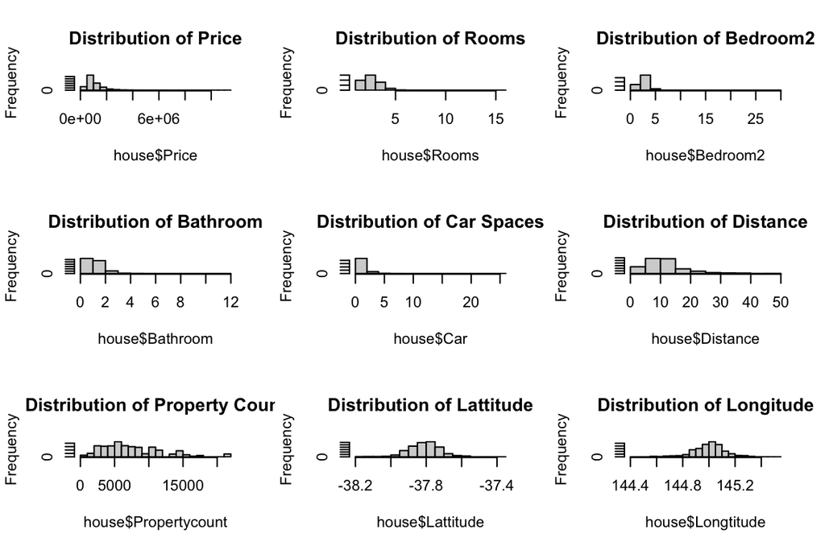

```r
# Histograms of numeric variables (3x3 layout)
par(mfrow = c(3,3))
hist(house$Price, main = "Distribution of Price")
hist(house$Rooms, main = "Distribution of Rooms")
hist(house$Bedroom2, main = "Distribution of Bedroom2")
hist(house$Bathroom, main = "Distribution of Bathroom")
hist(house$Car, main = "Distribution of Car Spaces")
hist(house$Distance, main = "Distribution of Distance")
hist(house$Propertycount, main = "Distribution of Property Count")
hist(house$Lattitude, main = "Distribution of Lattitude")
hist(house$Longtitude, main = "Distribution of Longitude")
```

### 3.1.3 Analysis of Categorical Variables

For the categorical variables we are going to look at tables containing the distribution of each of the categorical options and commenting on that distribution.

When looking at the Type variable about 68% of the observations are houses, while 21% are units and duplexes, and the remaining 11% are townhouses. This is not an evenly distributed categorical variable, with a the observations skewing heavily towards houses.

```r
table(house$Type)
```

```
    h     t     u
23980  3580  7297
```

```r
table(house$Method)
```

```
   PI    PN     S    SA    SN    SP    SS    VB     W
 4850   308 19744   226  1317  5095    36  3108   173
```

```r
table(house$Regionname)
```

```
                      #N/A       Eastern Metropolitan
                         3                       4377
          Eastern Victoria      Northern Metropolitan
                       228                       9557
         Northern Victoria South-Eastern Metropolitan
                       203                       1739
     Southern Metropolitan       Western Metropolitan
                     11836                       6799
          Western Victoria
                       115
```

### 3.1.4 Pairwise Association

With the size of this data set being over 30,000 observations, a pairwise scatter plot is unfortunately not that clear and legible for analysis, instead it makes for sense to look at correlation using a heat map, which is easier to read with this amount of observations. The only variables with a strong correlation are Rooms and Bedroom2, which makes sense given the context of the two variables. Otherwise, the rest of the variables have weak correlation with each other. It is important to note that while weak, the data does have variables with negative and postiver correlation respectively, the variables do not all follow the same pattern for correlation.

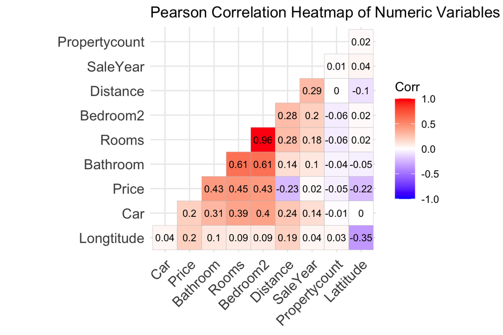

```r
numeric_vars <- house %>%
  select(Price, Rooms, Bedroom2, Bathroom, Car, Distance, Propertycount, Lattitude, Longtitude, SaleYear)

# Pearson correlation matrix
corr_mat_pearson <- cor(numeric_vars, use = "complete.obs", method = "pearson")

# Pearson correlation heatmap
ggcorrplot(corr_mat_pearson,
           hc.order = TRUE,
           type = "lower",
           lab = TRUE,
           lab_size = 3,
           method = "square",
           colors = c("blue", "white", "red"),
           title = "Pearson Correlation Heatmap of Numeric Variables",
           ggtheme = theme_minimal)
```

## 3.2 Feature Engineering

After conducting the examination on the data through our exploratory data analysis we were able to make the determination on what kinds feature engineering steps need to be taken. Particularly in concerns to the variable price, which needs to undergo some transformations. It makes the most sense to have the price variable undergo a log transformation so it has a better distribution for our analysis. Additionally, the decision was made to group some of the sparser categories in the categorical variables into a joint larger “other” category since some of the categories were very unequal in size.

```r
house <- house %>%
  mutate(
    LogPrice = log1p(Price),
  )

rare_councils <- names(sort(table(house$CouncilArea), decreasing = FALSE)[
  sort(table(house$CouncilArea), decreasing = FALSE) < 100
])
house <- house %>%
  mutate(CouncilAreaGrouped = ifelse(CouncilArea %in% rare_councils, "Other", CouncilArea))

# Suburb: group suburbs with few observations into "Other"
rare_suburbs <- names(sort(table(house$Suburb), decreasing = FALSE)[
  sort(table(house$Suburb), decreasing = FALSE) < 50
])
house <- house %>%
  mutate(SuburbGrouped = ifelse(Suburb %in% rare_suburbs, "Other", Suburb))

# 3. Convert SellerG into binary variable: big seller = 1, small seller = 0
# Define big sellers (top 10 agencies by number of sales)
top_sellers <- names(sort(table(house$SellerG), decreasing = TRUE)[1:10])
house <- house %>%
  mutate(SellerBinary = ifelse(SellerG %in% top_sellers, 1, 0))
```

# 4 Results and Conclusions